# Task10

#### (c) Why is multiplicative seasonality necessary here?

The multiplicative seasonality is necessary here because of the fact, that seasonal variation in the data is increasing. Additive method does not cover increasing seasonal variation.

#### (d) Experiment with making the trend exponential and/or damped.

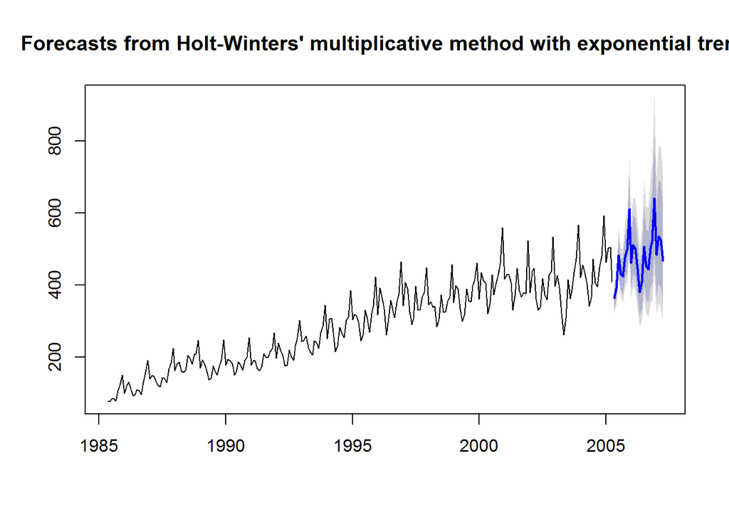

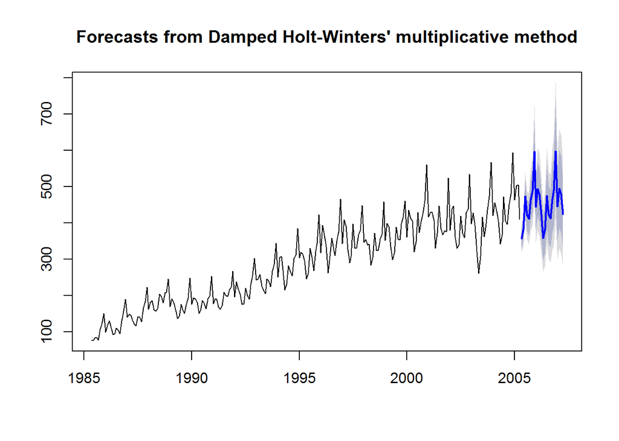

#### (e) Compare the RMSE of the one-step forecasts from the various methods. Which do you prefer?

Holt-Winters

```
##                      ME     RMSE      MAE        MPE     MAPE      MASE
## Training set -0.8614726 14.52211 10.86884 -0.4799156 4.168399 0.4013761
##                     ACF1
## Training set -0.03448764
```

Holt-Winters exponential

```
##                      ME    RMSE      MAE        MPE     MAPE     MASE
## Training set -0.6175624 14.6899 11.00618 -0.3558085 4.230296 0.406448
##                    ACF1
## Training set 0.08654357
```

Holt-Winters damped

```
##                    ME     RMSE      MAE       MPE     MAPE      MASE
## Training set 1.523643 14.40219 10.64283 0.3591333 4.057262 0.3930297
##                    ACF1
## Training set 0.01526565
```

The RMSE of damped model is lowest, so I would prefer $fit_hwd$ model.

#### (f) Check that the residuals from the best model look like white noise.

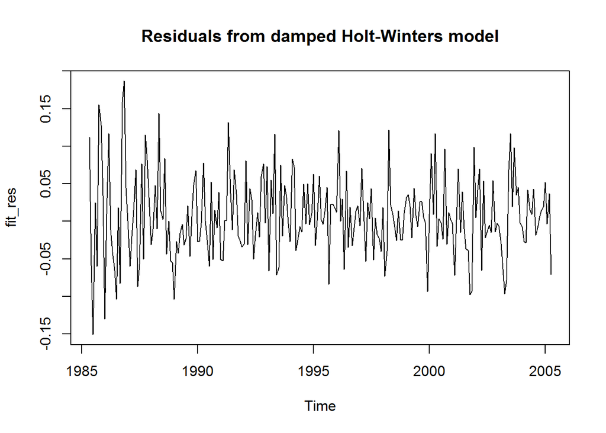

```
## [1] 0.006491946
```

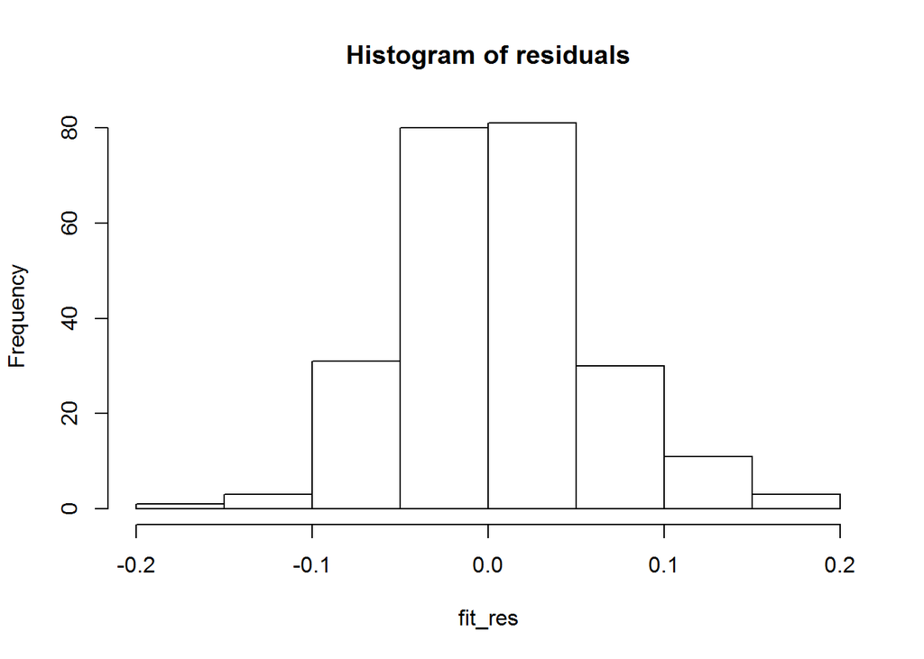

```
##
##  Shapiro-Wilk normality test
##
## data:  as.vector(fit_res)
## W = 0.9856, p-value = 0.01569
```

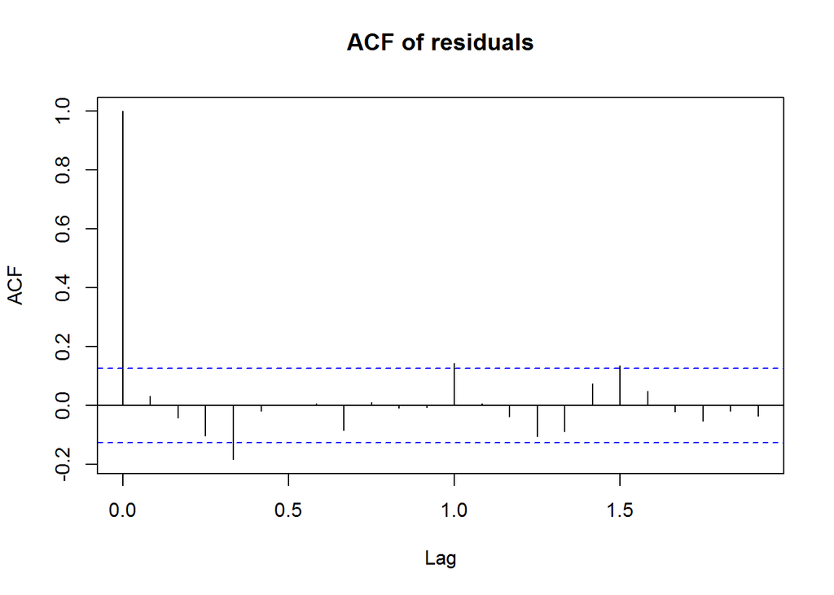

```
##
##  Box-Ljung test
##
## data:  fit_res
## X-squared = 35.4973, df = 24, p-value = 0.06136
```